# HBHC - 4.3.3 - Teringie and Waltowa abundance models

Thomas Prowse - thomas.prowse@adelaide.edu.au

15/12/2021

This R script plots the very limited waterbird data for Teringie (South and North) and Waltowa wetlands that could be matched to surface water imagery available for the month in which waterbird surveys are conducted. The script also summarises the selected waterbird abundance model for each of five considered species, as was presented in report 4.3.2 of the Healthy Coorong, Healthy Basin Program.

Please set the R working directory to the ‘Teringie and Waltowa’ folder before running the R script “TeringieWaltowa.R”.

# Load packages

```r
# If any of these packages are not installed, use install.packages("package name") before uploading them

rm(list=ls())
library(raster)
library(mgcv)
library(ggplot2)
library(lubridate)
library(scales)
library(reshape2)
```

# Load models and data

## Load waterbird data

```r
waterbirds <- readRDS('waterbirds.rds')
```

*waterbirds* is a data frame of waterbird abundance counts at each of the wetlands, along with ancillary data on covariates at the time of surveys.

## Load selected models for each species

```r
fit <- readRDS('Best models based on AIC.rds')
```

*fit* is a list object (with 5 elements) containing the selected model for each species. The species are ordered sequentially by their common name, as follows: AP, Australian pelican; BS, black swan; RCP, red-capped plover; RNS, red-necked stint; STS, sharp-tailed sandpiper.

# Plot the waterbird data at each wetland against proportional water coverage

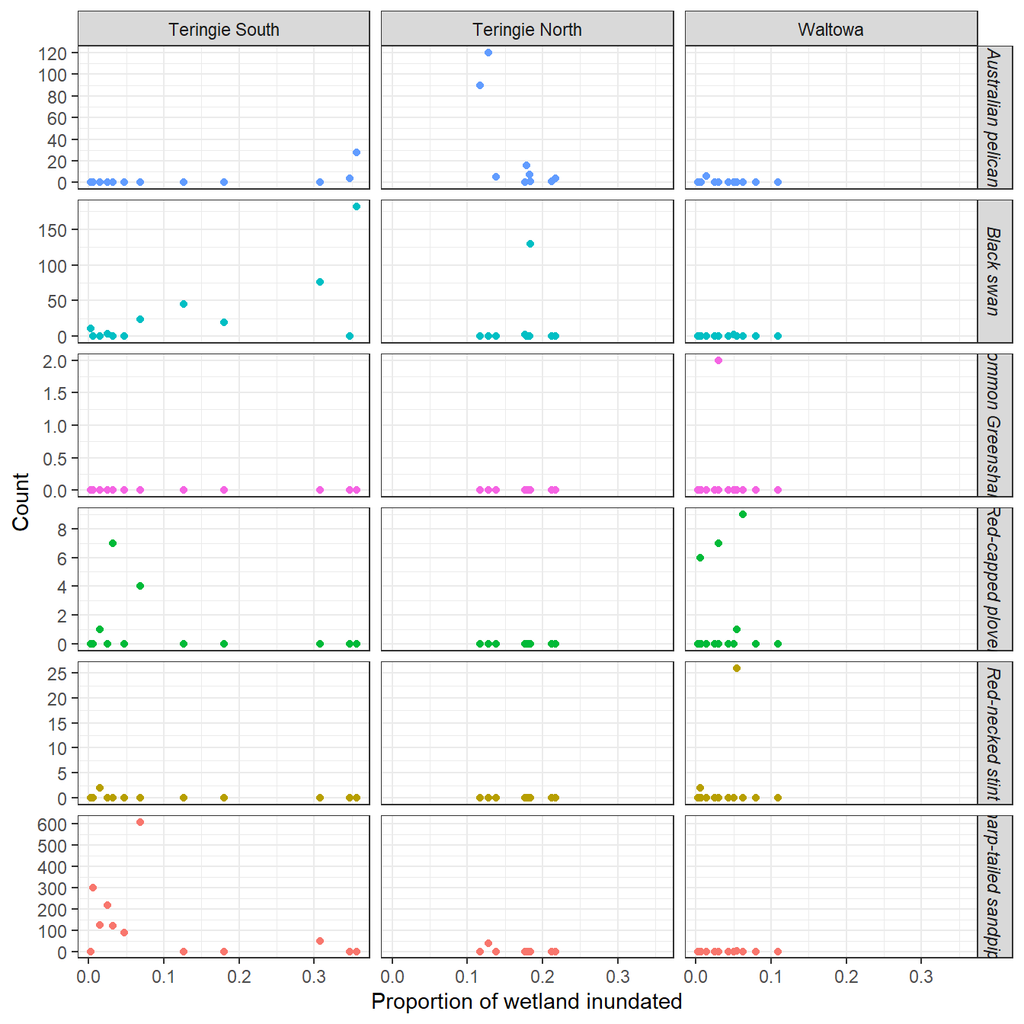

```r
(p1 <- ggplot(waterbirds, aes(PropCoverage, n, colour=Taxa_SpeciesName)) + geom_point() +
  facet_grid(Species~Wetland_Name, scales='free_y') +
  guides(colour='none') +
  xlab('Proportion of wetland inundated') + ylab('Count') +
  labs(colour='Wetland') + scale_y_continuous(breaks= pretty_breaks()) +
  theme_bw() + theme(strip.text.y = element_text(face = "italic")))
```

# Print model summaries

```r
lapply(1:length(fit), function(x) {
  print(paste('*******',names(fit)[x],'*******'))
  print(summary(fit[[x]]))
  print(paste('*****************************'))
})
```

```
## [1] "******* AP *******"
##
## Family: Negative Binomial(0.378)
## Link function: log
##
## Formula:
## y ~ Wetland + s(AreaGreater20, by = Wetland)
##
## Parametric coefficients:
##                       Estimate Std. Error z value Pr(>|z|)
## (Intercept)             -13.00      12.14  -1.071    0.284
## WetlandTeringie North    18.28      12.22   1.496    0.135
## WetlandWaltowa          -91.73      72.18  -1.271    0.204
##
## Approximate significance of smooth terms:
##                                        edf Ref.df Chi.sq p-value
## s(AreaGreater20):WetlandTeringie South   1      1  1.588  0.2075
## s(AreaGreater20):WetlandTeringie North   1      1  5.555  0.0184 *
## s(AreaGreater20):WetlandWaltowa          1      1  2.163  0.1412
## ---
## Signif. codes:  0 '***' 0.001 '**' 0.01 '*' 0.05 '.' 0.1 ' ' 1
##
## R-sq.(adj) =  0.718   Deviance explained = 82.9%
## -REML = 36.616  Scale est. = 1         n = 35
## [1] "*****************************"
## [1] "******* BS *******"
##
## Family: Negative Binomial(0.119)
## Link function: log
##
## Formula:
## y ~ Wetland + s(PropCoverage, k = 3, by = Wetland)
##
## Parametric coefficients:
##                        Estimate Std. Error z value Pr(>|z|)
## (Intercept)              2.4531     0.8584   2.858  0.00426 **
## WetlandTeringie North -157.4528   174.2833  -0.903  0.36630
## WetlandWaltowa          -2.9798     3.7742  -0.790  0.42980
## ---
## Signif. codes:  0 '***' 0.001 '**' 0.01 '*' 0.05 '.' 0.1 ' ' 1
```

[output cut: 57 more lines]

```
## (Intercept)              4.6023     0.9324   4.936 7.97e-07 ***
## WetlandTeringie North    3.0164     5.2448   0.575    0.565
## WetlandWaltowa        -379.1441   676.2016  -0.561    0.575
## ---
## Signif. codes:  0 '***' 0.001 '**' 0.01 '*' 0.05 '.' 0.1 ' ' 1
##
## Approximate significance of smooth terms:
##                                         edf Ref.df Chi.sq p-value
## s(PropCoverage):WetlandTeringie South 1.000  1.000  1.918   0.166
## s(PropCoverage):WetlandTeringie North 1.000  1.000  1.087   0.297
## s(PropCoverage):WetlandWaltowa        1.424  1.669  0.496   0.761
##
## R-sq.(adj) =  0.165   Deviance explained = 72.4%
## -REML = 54.862  Scale est. = 1         n = 35
## [1] "*****************************"
```

```
## [[1]]
## [1] "*****************************"
##
## [[2]]
## [1] "*****************************"
##
## [[3]]
## [1] "*****************************"
##
## [[4]]
## [1] "*****************************"
##
## [[5]]
## [1] "*****************************"
```